# Reproductive Health Equity Analysis with DHS-Style Survey Data

A reproducible R + Quarto portfolio project

Author

Akewak Jeba (Aki)

Published

September 30, 2026

## Project overview

This portfolio project demonstrates how to analyse **complex population survey data** in R using a DHS-style structure. It focuses on reproductive-health equity and shows how survey weights, strata, and clusters affect estimation.

> **Important:** The repository includes a **synthetic DHS-like dataset** so the project runs immediately. It does **not** represent any real country or respondents. For a more authentic practice workflow, replace it with an official DHS model dataset from The DHS Program.

### Questions

1. What is the weighted prevalence of modern contraceptive use?
2. Does use differ between urban and rural respondents?
3. How does use vary by educational attainment?
4. Are differences still visible after considering age, residence, education, and wealth?

## Setup

```r
packages <- c("tidyverse", "survey", "srvyr", "scales", "broom")

to_install <- packages[!packages %in% rownames(installed.packages())]
if (length(to_install) > 0) install.packages(to_install)

library(tidyverse)
library(survey)
library(srvyr)
library(scales)
library(broom)

theme_set(theme_minimal(base_size = 13))
```

## Data

```r
dat <- read_csv("data/synthetic_dhs_like.csv", show_col_types = FALSE) |>
  mutate(
    weight = weight_raw / 1e6,
    modern_contraceptive_use = as.numeric(modern_contraceptive_use),
    residence = factor(residence),
    education = factor(
      education,
      levels = c("No education", "Primary", "Secondary", "Higher")
    ),
    wealth = factor(
      wealth,
      levels = c("Lowest", "Second", "Middle", "Fourth", "Highest")
    )
  )

glimpse(dat)
```

```
Rows: 1,800
Columns: 10
$ cluster                  <dbl> 11, 93, 79, 53, 52, 104, 11, 84, 25, 12, 64, …
$ strata                   <dbl> 1, 6, 6, 4, 2, 1, 1, 6, 2, 12, 3, 8, 9, 6, 11…
$ weight_raw               <dbl> 940164, 1196019, 490437, 1216496, 1683349, 45…
$ age                      <dbl> 44, 39, 38, 33, 15, 28, 40, 43, 34, 39, 15, 3…
$ residence                <fct> Urban, Urban, Rural, Urban, Rural, Urban, Urb…
$ education                <fct> Secondary, Primary, Primary, No education, Se…
$ wealth                   <fct> Lowest, Second, Second, Second, Highest, Lowe…
$ married_or_union         <dbl> 0, 0, 1, 1, 1, 0, 1, 1, 1, 1, 1, 1, 1, 1, 0, …
$ modern_contraceptive_use <dbl> 0, 0, 0, 0, 0, 1, 0, 1, 0, 0, 0, 0, 1, 0, 0, …
$ weight                   <dbl> 0.940164, 1.196019, 0.490437, 1.216496, 1.683…
```

### Why survey design matters

Large household surveys typically use multistage sampling rather than simple random sampling. Analyses therefore need to account for:

- **weights** to represent the target population,
- **strata** used in sample design,
- **clusters / primary sampling units** that induce correlation among observations.

Ignoring these can produce incorrect population estimates and standard errors.

## Define the survey design

```r
options(survey.lonely.psu = "adjust")

des <- dat |>
  as_survey_design(
    ids = cluster,
    strata = strata,
    weights = weight,
    nest = TRUE
  )
```

## Weighted prevalence

```r
overall <- des |>
  summarise(
    prevalence = survey_mean(
      modern_contraceptive_use,
      vartype = c("ci"),
      na.rm = TRUE
    )
  )

overall |>
  mutate(across(c(prevalence, prevalence_low, prevalence_upp), percent, accuracy = 0.1))
```

```
# A tibble: 1 × 3
  prevalence prevalence_low prevalence_upp
  <chr>      <chr>          <chr>
1 33.0%      30.7%          35.4%
```

The weighted estimate above should be interpreted as a population-level estimate under the survey design rather than as the raw proportion in the sample.

## Urban-rural comparison

```r
by_residence <- des |>
  group_by(residence) |>
  summarise(
    prevalence = survey_mean(
      modern_contraceptive_use,
      vartype = c("ci"),
      na.rm = TRUE
    )
  )

by_residence |>
  mutate(across(c(prevalence, prevalence_low, prevalence_upp), percent, accuracy = 0.1))
```

```
# A tibble: 2 × 4
  residence prevalence prevalence_low prevalence_upp
  <fct>     <chr>      <chr>          <chr>
1 Rural     29.4%      26.4%          32.4%
2 Urban     38.4%      34.5%          42.3%
```

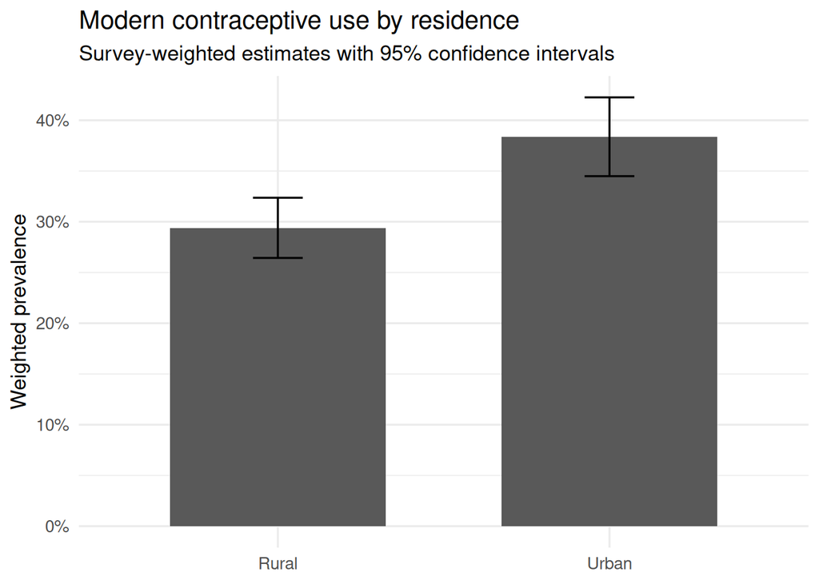

Weighted modern contraceptive use by residence

```r
ggplot(by_residence, aes(x = residence, y = prevalence)) +
  geom_col(width = 0.65) +
  geom_errorbar(
    aes(ymin = prevalence_low, ymax = prevalence_upp),
    width = 0.15
  ) +
  scale_y_continuous(labels = percent, limits = c(0, NA)) +
  labs(
    x = NULL,
    y = "Weighted prevalence",
    title = "Modern contraceptive use by residence",
    subtitle = "Survey-weighted estimates with 95% confidence intervals"
  )
```

## Education gradient

```r
by_education <- des |>
  group_by(education) |>
  summarise(
    prevalence = survey_mean(
      modern_contraceptive_use,
      vartype = c("ci"),
      na.rm = TRUE
    )
  )

by_education |>
  mutate(across(c(prevalence, prevalence_low, prevalence_upp), percent, accuracy = 0.1))
```

```
# A tibble: 4 × 4
  education    prevalence prevalence_low prevalence_upp
  <fct>        <chr>      <chr>          <chr>
1 No education 22.8%      18.0%          27.7%
2 Primary      26.7%      22.7%          30.6%
3 Secondary    39.3%      35.5%          43.2%
4 Higher       50.6%      42.1%          59.0%
```

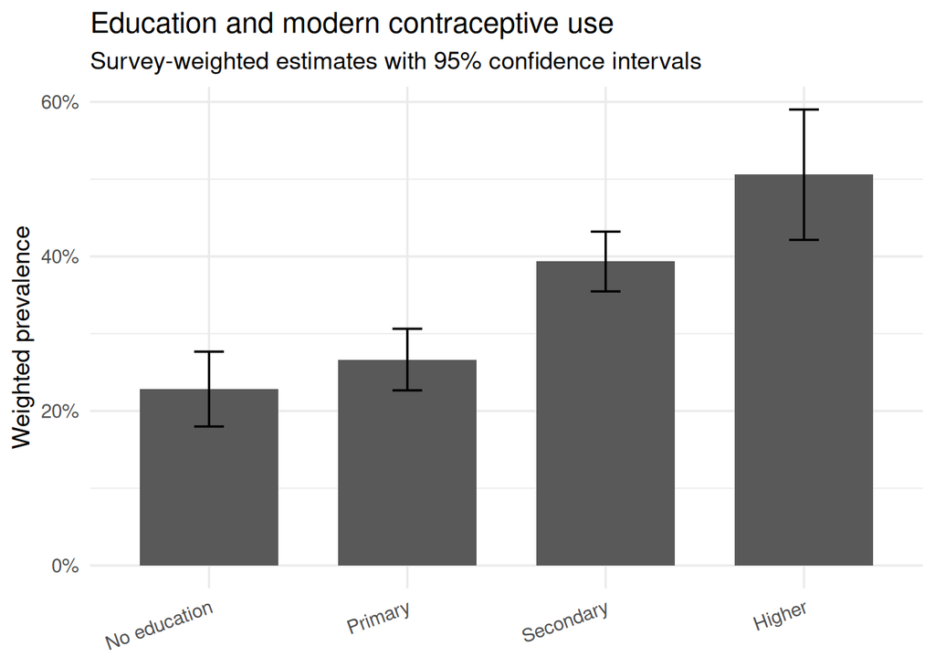

Weighted modern contraceptive use by education

```r
ggplot(by_education, aes(x = education, y = prevalence)) +
  geom_col(width = 0.7) +
  geom_errorbar(
    aes(ymin = prevalence_low, ymax = prevalence_upp),
    width = 0.15
  ) +
  scale_y_continuous(labels = percent, limits = c(0, NA)) +
  labs(
    x = NULL,
    y = "Weighted prevalence",
    title = "Education and modern contraceptive use",
    subtitle = "Survey-weighted estimates with 95% confidence intervals"
  ) +
  theme(axis.text.x = element_text(angle = 20, hjust = 1))
```

## Multivariable model

A survey-weighted logistic regression can be used to examine associations while accounting for major sociodemographic characteristics.

```r
fit <- survey::svyglm(
  modern_contraceptive_use ~ age + residence + education + wealth,
  design = des,
  family = quasibinomial()
)

model_results <- tidy(fit, conf.int = TRUE, exponentiate = TRUE) |>
  filter(term != "(Intercept)") |>
  select(term, estimate, conf.low, conf.high, p.value)

model_results
```

```
# A tibble: 9 × 5
  term               estimate conf.low conf.high     p.value
  <chr>                 <dbl>    <dbl>     <dbl>       <dbl>
1 age                   0.986    0.975     0.996 0.00880
2 residenceUrban        1.51     1.21      1.90  0.000375
3 educationPrimary      1.28     0.899     1.82  0.171
4 educationSecondary    2.23     1.62      3.09  0.00000133
5 educationHigher       3.38     2.16      5.29  0.000000121
6 wealthSecond          1.22     0.843     1.77  0.288
7 wealthMiddle          1.10     0.764     1.58  0.615
8 wealthFourth          1.49     1.05      2.12  0.0261
9 wealthHighest         1.85     1.31      2.61  0.000529
```

Here, exponentiated coefficients are odds ratios. They describe associations in this synthetic practice dataset and must **not** be interpreted as evidence about any real population.

## Reproducibility checks

```r
tibble(
  rows = nrow(dat),
  clusters = n_distinct(dat$cluster),
  strata = n_distinct(dat$strata),
  missing_outcome = sum(is.na(dat$modern_contraceptive_use))
)
```

```
# A tibble: 1 × 4
   rows clusters strata missing_outcome
  <int>    <int>  <int>           <int>
1  1800      120     12               0
```

## Policy-facing summary

For a real country dataset, a concise evidence translation section could report:

- the population-weighted level of modern contraceptive use;
- which population groups show lower use;
- the size and uncertainty of observed differences;
- whether disparities persist after adjustment;
- which findings are descriptive versus inferential;
- limitations of survey design, measurement, and cross-sectional data.

A policy brief should avoid causal claims unless the study design supports them.

## How to use an official DHS model dataset

The DHS Program provides **model datasets for practice** that do not represent real countries or respondents. After downloading an Individual Recode model dataset, replace the synthetic CSV import with the relevant `.DTA` file and map the DHS recode variables to the variables used in this report.

A common workflow is:

```r
library(haven)

dhs <- read_dta("data/ZZIR62FL.DTA")

# Example pattern only: verify every variable against the DHS recode manual.
# v001 = cluster / PSU
# v005 = sample weight (typically divide by 1,000,000)
# v021/v022 or related variables may be used for survey design depending on file/phase
# v025 = residence
# v106 = education
# v190 = wealth index

# Never map variables blindly; verify them using the official recode documentation.
```

## Skills demonstrated

This project demonstrates:

- R statistical programming
- complex survey analysis
- survey weighting, clustering, and stratification
- reproductive-health indicator analysis
- data cleaning and transformation
- weighted visualization
- survey-weighted regression
- reproducible research with Quarto
- research-to-policy evidence translation
- transparent documentation and limitations

## Repository structure

```
dhs-reproductive-health-quarto/
├── analysis.qmd
├── _quarto.yml
├── README.md
├── LICENSE
├── .gitignore
└── data/
    ├── synthetic_dhs_like.csv
    └── README.md
```

## Disclaimer

The included dataset is synthetic and is provided solely for demonstration. It is not a DHS country dataset and must not be used to make claims about any country, population, or health program.